# HW_1

## Data Science 1 HW1

Vyas Ramankulangara

1592440

```r
install.packages("MASS")
library(MASS)
install.packages("RColorBrewer")
library(RColorBrewer)
install.packages("KernSmooth")
library(KernSmooth)
install.packages("caTools")
library(caTools)
install.packages("dplyr")
library(dplyr)
install.packages("rpart")
library(rpart)
install.packages("moments")
library(moments)
```

# Number 1

```r
# Importing data
dataset <- read.table(file = "data.dat", header = FALSE)
selected_data <- dataset[c(1,2,18)]
```

```r
#Calculate covariance matrix
c <- cov(selected_data)
c
correlation <- cor(selected_data)
correlation
```

|  | V1 | V2 | V18 |
| --- | --- | --- | --- |
| V1 | 67.80657 | 35.201637 | 22.391727 |
| V2 | 35.20164 | 38.067242 | 1.775135 |
| V18 | 22.39173 | 1.775135 | 55.335707 |

|  | V1 | V2 | V18 |
| --- | --- | --- | --- |
| V1 | 1.0000000 | 0.69286923 | 0.36555185 |
| V2 | 0.6928692 | 1.00000000 | 0.03867702 |
| V18 | 0.3655518 | 0.03867702 | 1.00000000 |

### Analysis:

Correlation is nothing but covariance divided by standard deviation.In the correlation matrix, we can see the relationship between the attributes V1 and V1 is 1 since they are the same attribute and they are related. Any number closer to 1 shows high relation to each other for instance V1 and V2 show high relation.

# Number 2

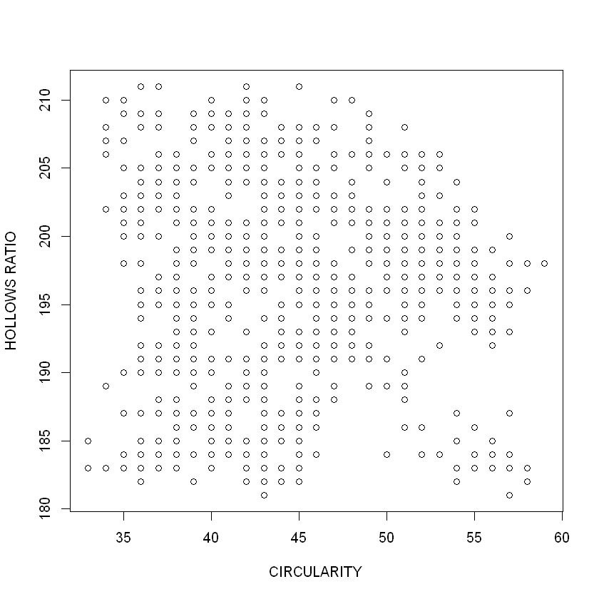

```r
# Scatter plot
plot(dataset$V2,dataset$V18, xlab = "CIRCULARITY", ylab = "HOLLOWS RATIO")
```

### Analysis:

There are no correlation between CIRCULARITY and HOLLOWS RATIO. By observing the graph the values are spread out.

# Number 3

0.380594287659102

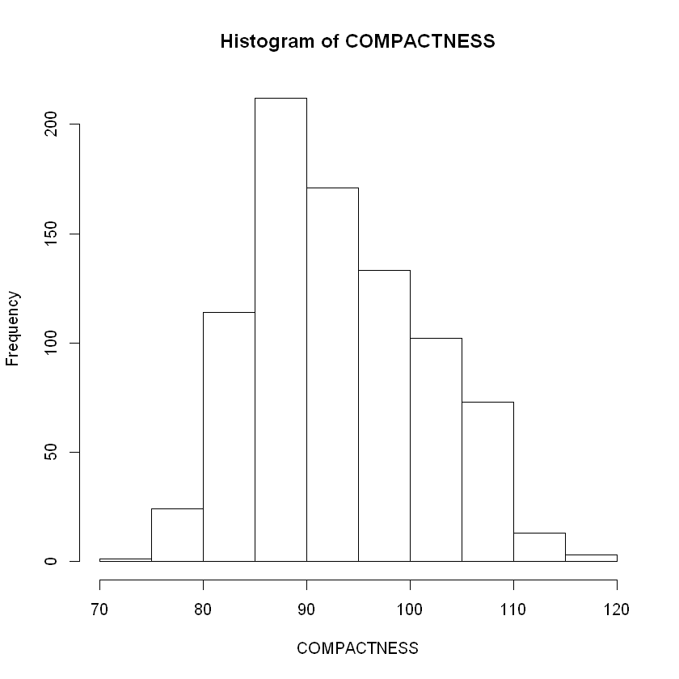

0.262332593782417

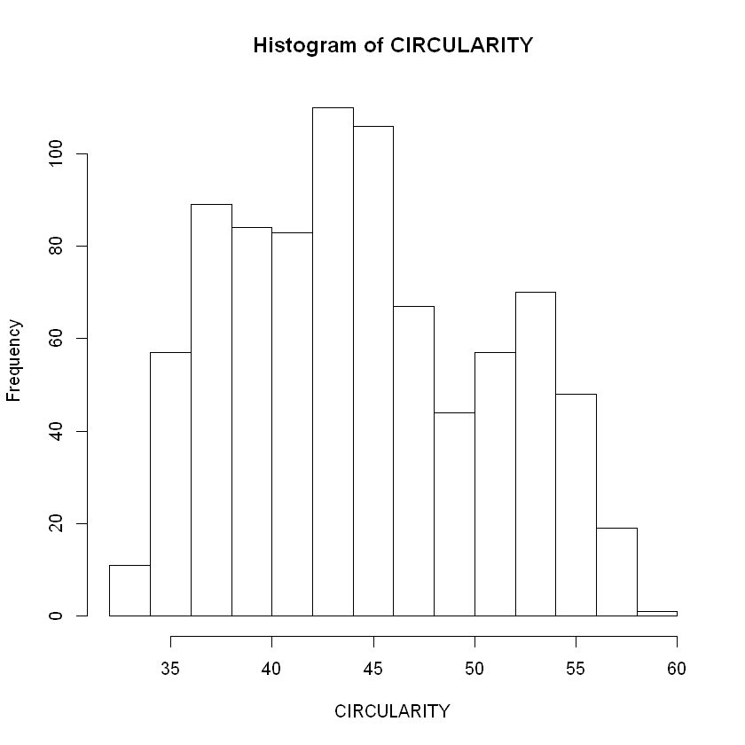

```r
# Histogram
hist(dataset$V1, main = "Histogram of COMPACTNESS", xlab = "COMPACTNESS", ylab = "Frequency")
skewness(dataset$V1)
hist(dataset$V2, main = "Histogram of CIRCULARITY", xlab = "CIRCULARITY", ylab = "Frequency")
skewness(dataset$V2)
```